# Income Gap Between Sexes

Samuel Taylor

## Question

How does income compare between sexes?

## Data

Adult Fairness Dataset - One row is one person (5000 Rows);

## Income Gap Between Sexes

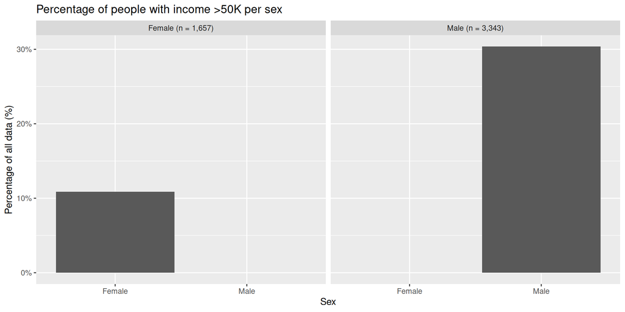

Figure 1

## Ages of Occurrences

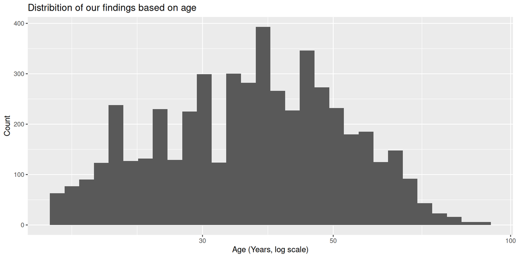

Figure 2

## Marital Status Panelled

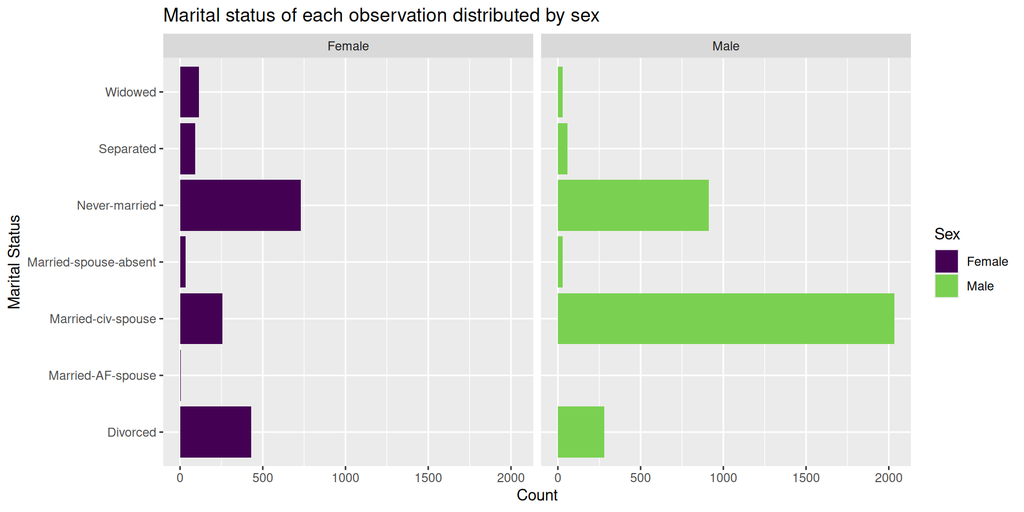

Figure 3

## Mean hours worked in a week by marital status

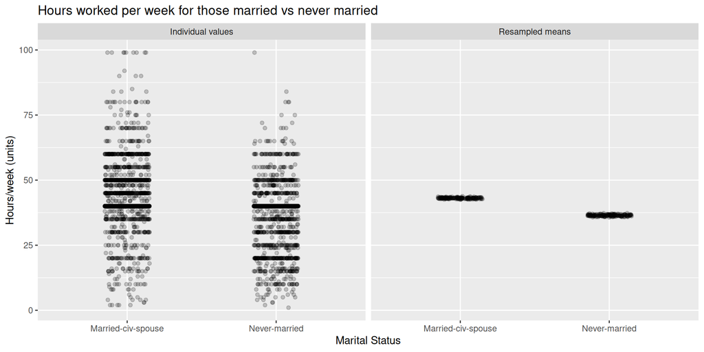

Figure 4

## Limits

- The data comes from the DOI. The dataset contains occurrences from 3343 males and 1657 females, about half as many females as males. The data shows us how many make over 50K a year, what kind of employment, education, and marital status; however, it does not tell us the exact job, the family dynamics, the area of living, or the presence of children.

## Sources and AI use

- Becker, B. & Kohavi, R. (1996). *Adult* [Dataset]. UCI Machine Learning Repository. https://doi.org/10.24432/C5XW20. Accessed through Fairlearn (`fetch_adult`).
- No AI was used for this project.